# Homework

SA24204132

2024-12-04

## HW1

### Answers 3.4

This part gives the answer to question 3.4 in page 94. We can easily inferred that the cumulative distribution function of this distribution is as followed. As is demonstrated in the formula, the cdf is a continuously one-one mapping so that the inverse transform method maybe proper.

$$CDF:F(x) =
1-exp\{-\frac{x^2}{2\sigma^2}\}$$

$$Inverse\
transformed:F^{-1}(x)=\sqrt{-2\sigma^2ln(1-x)}$$

The algorithm to generate 5000 random numbers is shown in the code chunk. `Sys.time` was used to get the system time as the random seed. Then use `runif` to create 5000 Uniform(0,1) variables before transforming them into what we need. The second formula present that how we will treat them. The parameter $\sigma$ is set as 1 while it can be changed to whatever you wished. Finally, we can see in the histogram that the mode of the random numbers we made is 1, very closed to the theoretical mode $\sigma=1$.

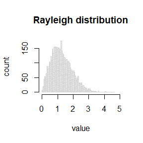

```r
set.seed(Sys.time())
r <- runif(5000)
sigma <- 1
x <- sqrt(-2 * sigma^2 * log(1-r))
hist(x,density = 50,xlim = c(0, 5),xlab = 'value',ylab = 'count',main = 'Rayleigh distribution', nclass = 100)
```

### 3.11

$X_1$ has the distribution of Normal(0,1), $X_2$ has the distribution of Normal(3,1). $\Phi_i(x),i=1,2$ is the respective cumulative distribution function of two normal variables. After that we build a U(0, 1) variable to apply in a conditional acceptance statement `as.integer(u>p1)` for simulating the mixture distribution of $X_1$ and $X_2$. If u is bigger(or smaller) than p1, then the result will be 1(or 0), so the number turn to be a N(0,1)(or N(3,1)) variable.

$$X_1 \sim N(0,1),\quad X_2 \sim
N(3,1)$$

$$S \sim
F(x)=p_1*\Phi_1(x)+(1-p_1)\Phi_2(x)$$

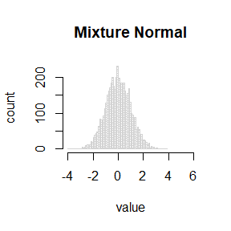

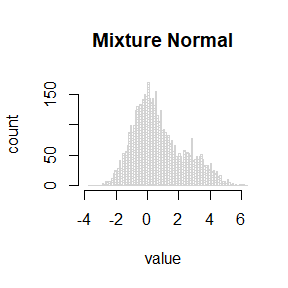

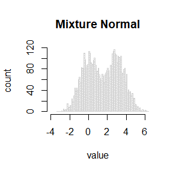

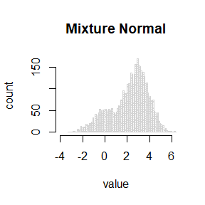

```r
set.seed(Sys.time())
p <- c(1,0.75,0.5,0.25)
i <- 1
while (i <= 4) {
  x1 <- rnorm(5000,mean = 0,sd = 1)
  x2 <- rnorm(5000,mean = 3,sd = 1)
  u <- runif(5000)
  k <- as.integer(u > 1-p[i])
  y <- k*x1 + (1-k)*x2
  hist(y,density = 50,xlim = c(-4,6),xlab = 'value',ylab = 'count',main = 'Mixture Normal', nclass = 100)
  i <- i + 1
}
```

As we can see in the plots, the histogram with p equal to 0.75 does not show an apparent signature to be bimodal. But when p turns to be 0.5, it seems to have two modes in the distribution.

### 3.20

In this question, I use a `for` iteration to create a vector filled with a compound Poisson($\lambda$)-Gamma process required. The final output contains both the theoretical values and the simulated values of x(10) process. On conclusion, they are quite similar to each other with a sample size of 5000.

```r
set.seed(Sys.time())
t <- 10; lamda <- 1; a <- 1; r <- 1
x <- c()
for (i in 1:5000)
{
  n <- rpois(1,t*lamda)
  y <- 0
  for (j in 1:n)
  {
    y <- y + rgamma(1,a,r)
  }
  x[i] <- y
}
x_miu <- t * lamda * a / r
x_miu
```

```
## [1] 10
```

```r
x_bar <- mean(x)
x_bar
```

```
## [1] 10.01129
```

```r
x_sigmasquare <- t * lamda * (a/r^2 + a^2/r^2)
x_sigmasquare
```

```
## [1] 20
```

```r
x_ssquare <- var(x)
x_ssquare
```

```
## [1] 20.30371
```

## HW2

### Exercise

The cumulative distribution function of X with $Beta(a,b)$ is presented below.

$$F(x)=\int_{0}^{x}t^{a-1}(1-t)^{b-1}dt
\quad x\in(0,1)$$

In this part, I use the simple Monte Carlo method to compute the possible value of the cdf with some giving parameters.

```r
# Write a function to compute the Monte Carlo estimate of cdf
mc_cdfbeta <- function(x,a,b){
  set.seed(Sys.time())
  n <- 20000
  u <- x*runif(n)
  y <- (gamma(a+b)/(gamma(a)*gamma(b)))*u^(a-1)*(1-u)^(b-1)*x
  estimate <- mean(y)
  return(round(estimate,5))
}

# Compute the result of giving parameter x using the function
m <- c(0.1,0.2,0.3,0.4,0.5,0.6,0.7,0.8,0.9)
c1 <- c()
c2 <- c()
for(i in 1:length(m))
{
  c1[i] <- mc_cdfbeta(m[i],3,3)
  c2[i] <- pbeta(m[i],3,3)
}
```

The results are shown below the code chunk. c1 is the simulated value, while c2 is the theoretic value computed by R through `pbeta(x,a,b)`. We can see that the two values with each given parameter are so closed.

```r
c1
```

```
## [1] 0.00847 0.05737 0.16167 0.31502 0.49679 0.67924 0.83449 0.94172 0.99414
```

```r
c2
```

```
## [1] 0.00856 0.05792 0.16308 0.31744 0.50000 0.68256 0.83692 0.94208 0.99144
```

### 5.9

$$CDF:F(x) =
1-exp\{-\frac{x^2}{2\sigma^2}\}$$

$$Inverse\
transformed:F^{-1}(x)=\sqrt{-2\sigma^2ln(1-x)}$$

We use the inverse method to create i.i.d variables in Rayleigh distribution with the sample size of n. In the function, 5000 $U(0,1)$ numbers $u_1$ are created to generate Rayleigh distribution random numbers $X_1$. Variable $u_1^{anti}=1-u_1$ are made as a preparation for the antithetic variable $X_1^{anti}$. In the function, another 5000 Rayleigh random numbers are created to show the performance of common method. Eventually, the function will return a ratio to display to what extent the antithetic method will reduce the variance of the estimate.

```r
antirayleigh <- function(sigma){
  set.seed(Sys.time())
  n <- 5000

  # Antithetic variables method
  u1 <- runif(n)
  u2 <- 1-u1
  x1 <- sqrt(-2 * sigma^2 * log(1-u1))
  x1_anti <- sqrt(-2 * sigma^2 * log(1-u2))
  antix <- (x1+x1_anti)/2
  s1 <- var(antix)

  # Independent variables method
  u3 <- runif(n)
  x2 <- sqrt(-2 * sigma^2 * log(1-u3))
  indx <- (x1+x2)/2
  s2 <- var(indx)

  return(1-s1/s2)
}
```

Finally, we can see that the variance of antithetic variables can extremely reduce the variance.

```r
antirayleigh(1)
```

```
## [1] 0.9440937
```

### 5.13

$$g(x)=
\begin{cases}
\frac{x^2}{\sqrt{2\pi}}exp(-\frac{x^2}{2})& \text{x>1}\\
0& \text{x<=0}
\end{cases}$$

$$X_1\sim Ga(3,\frac{1}{2}) \quad
f_1(x)=\frac{x^2}{16}exp(-\frac{x}{2}) \quad
x\in(0,+\infty)$$

$$X_2\sim N(0,1) \quad
f_2(x)=\frac{1}{\sqrt{2\pi}}exp(-\frac{x^2}{2}) \quad
x\in(-\infty,+\infty)$$

Use `rgamma` and `rnorm` to create 50000 random numbers of $X_1$ and $X_2$ respectively. Then compute the value of the definite integral through importance sampling method.

```r
set.seed(Sys.time())
x1 <- rgamma(50000,3,0.5)
x2 <- rnorm(50000,mean = 0,sd = 1)
g_x1 <- ((16/sqrt(2*pi))*exp((x1-x1^2)/2))*(x1>1)
g_x2 <- x2^2*(x2>1)
```

```r
mean(g_x1)
```

```
## [1] 0.4076038
```

```r
mean(g_x2)
```

```
## [1] 0.4061758
```

```r
var(g_x1)
```

```
## [1] 1.225159
```

```r
var(g_x2)
```

```
## [1] 1.311461
```

### Monte Carlo experiment

Two sorting algorithms are written in this part including a fast sorting algorithm and a bubble sorting algorithm. Theoretically, they will acquire a time complexity of $O(nlog(n))$ and $O(n^2)$. So here I make two regressions of theoretical computing time to the practical computing time for the two different algorithms. There scatter plots with the regression line are also presented to visualize the result.

```r
quicksort <- function(x){
  set.seed(Sys.time())
  if(length(x)<=1)return(x)
  x0 <- x[1]
  n <- length(x)
  loc <- sample(1:n,size = 1,replace = F)
  low <- 1
  high <- n
  while(low != high){
    if(loc == low){
      if(x[high] < x[loc]){
        tmp <- x[high]
        x[high] <- x[loc]
        x[loc] <- tmp
        low = low+1
        loc = high
      }else{
        high = high - 1
      }
    }else{
      if(x[low] > x[loc]){
        tmp <- x[low]
        x[low] <- x[loc]
        x[loc] <- tmp
        high = high -1
        loc = low
      }else{
        low = low+1
      }
    }
  }
  L = c()
  R = c()
  if(low>1) L = x[1:(low-1)]
  if(low<length(x)) R = x[(low+1):n]
  return(c(quicksort(L),x[low],quicksort(R)))
}
bubblesort <- function(x){
  n <- length(x)
  if(n==1)
  {
    return(x)
  }
  for(i in 1:(n-1))
  {
    for(j in 1:(n-i))
    {
      if(x[j]>x[j+1])
      {
        temp <- x[j]
        x[j] <- x[j+1]
        x[j+1] <- temp
      }
    }
  }
  return(x)
}
fastersorting <- function(arr){
  set.seed(Sys.time())
  n <- length(arr)
  if (n<=1)
  {
    return(arr)
  }
  loc <- sample(1:n,size = 1,replace = F)
  pivot <- arr[loc]
  high <- n
  low <- 1

  #左指针向右移动直到出现第一个与pivot的错排停下
  while(arr[low]<pivot)
  {
    low <- low+1
  }

  #左边指针第一次停下移动，且此时指向一个比pivot大的值
  if(low!=loc)
  {
    arr[loc] <- arr[low]
    while(high>low)
    {
      while(arr[high]>=pivot & high>low)
      {
        high <- high-1
      }
      arr[low] <- arr[high]
      while(arr[low]<=pivot & high>low)
      {
        low <- low+1
      }
      arr[high] <- arr[low]
    }
    arr[low] <- pivot
  }
  else
  {
    if(loc!=high)
    {
      while(high>low)
      {
        while(arr[high]>=pivot & high>low)
        {
          high <- high-1
        }
        arr[low] <- arr[high]
        while(arr[low]<=pivot & high>low)
        {
          low <- low+1
        }
        arr[high] <- arr[low]
      }
      arr[low] <- pivot
    }
  }

  L = c()
  R = c()
  if(low>1) L = arr[1:(low-1)]
  if(low<n) R = arr[(low+1):n]
  return(c(fastersorting(L),arr[low],fastersorting(R)))
}
```

```r
x1 <- c()
x2 <- c()
y1 <- c()
y2 <- c()

for (i in 1:50)
{
  m <- i*10
  t1 <- c()
  t2 <- c()
  for(j in 1:100)
  {
    a <- sample(1:m,size = m,replace = F)
    sta1 <- Sys.time()
    fastersorting(a)
    end1 <- Sys.time()
    t1[j] <- end1-sta1
    sta2 <- Sys.time()
    bubblesort(a)
    end2 <- Sys.time()
    t2[j] <- end2-sta2
  }
  x1[i] <- m*log2(m)
  y1[i] <- mean(t1)
  x2[i] <- m^2
  y2[i] <- mean(t2)

}
relation1 <- lm(y1~x1)
relation2 <- lm(y2~x2)
print(summary(relation1))
```

```
##
## Call:
## lm(formula = y1 ~ x1)
##
## Residuals:
##        Min         1Q     Median         3Q        Max
## -2.127e-04 -6.531e-05 -1.340e-05  5.761e-05  3.803e-04
##
## Coefficients:
##              Estimate Std. Error t value Pr(>|t|)
## (Intercept) 2.788e-04  2.842e-05   9.809 4.74e-13 ***
## x1          8.792e-07  1.139e-08  77.166  < 2e-16 ***
## ---
## Signif. codes:  0 '***' 0.001 '**' 0.01 '*' 0.05 '.' 0.1 ' ' 1
##
## Residual standard error: 0.0001077 on 48 degrees of freedom
## Multiple R-squared:  0.992,  Adjusted R-squared:  0.9918
## F-statistic:  5955 on 1 and 48 DF,  p-value: < 2.2e-16
```

```r
print(summary(relation2))
```

```
##
## Call:
## lm(formula = y2 ~ x2)
##
## Residuals:
##        Min         1Q     Median         3Q        Max
## -1.161e-04 -2.110e-05  3.084e-06  1.868e-05  1.413e-04
##
## Coefficients:
##              Estimate Std. Error t value Pr(>|t|)
## (Intercept) 2.476e-05  1.123e-05   2.205   0.0323 *
## x2          2.846e-08  9.799e-11 290.449   <2e-16 ***
## ---
## Signif. codes:  0 '***' 0.001 '**' 0.01 '*' 0.05 '.' 0.1 ' ' 1
##
## Residual standard error: 5.26e-05 on 48 degrees of freedom
## Multiple R-squared:  0.9994, Adjusted R-squared:  0.9994
## F-statistic: 8.436e+04 on 1 and 48 DF,  p-value: < 2.2e-16
```

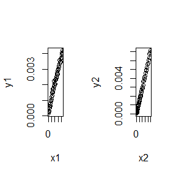

```r
par(mfrow=c(1, 2))
plot(x1,y1)
abline(lm(y1~x1))
plot(x2,y2)
abline(lm(y2~x2))
```

## HW3

### 6.6

I set a size of 10000 experiment to generate skewness sample from standard normal distribution. Then we can get 0.025, 0.05, 0.95, 0.975 quantiles respectively. Then we can compare them with the theoretical value under the large sample hypothesis.

```r
library(e1071)
set.seed(Sys.time())
n <- 1000; m <- 10000
p <- c(0.025,0.05,0.95,0.975)
q.ske <- q.lsa <- numeric(4)
for (i in 1:4) {
  skex <- numeric(m)
  for (j in 1:m) {
    x <- rnorm(n)
    skex[j] <- skewness(x)
  }
  q.ske[i] <- quantile(skex,probs = p[i])
  q.lsa[i] <- qnorm(p[i], 0, sqrt(6/n))
}
```

`q.ske` is for the empirical value while `q.lsa` is the large sample value.

```r
print(p)
```

```
## [1] 0.025 0.050 0.950 0.975
```

```r
print(q.ske)
```

```
## [1] -0.1520992 -0.1268254  0.1293655  0.1523773
```

```r
print(q.lsa)
```

```
## [1] -0.1518182 -0.1274098  0.1274098  0.1518182
```

### 6.B

A `for` circulate is used to generate Monte Carlo pseudo variables required for the experimental power of three correlation test, including parametric and non-parametric ones.

```r
library(MASS)
mu <- c(0, 0)
sigma <- matrix(c(1, 0.6, 0.6, 1), nrow = 2)
m <- 1000
method <- c("pearson", "kendall", "spearman")
power <- numeric(3)
p.pearson <- numeric(m)
p.kendall <- numeric(m)
p.spearman <- numeric(m)
for (j in 1:m) {
  data <- mvrnorm(n = 10, mu = mu, Sigma = sigma, empirical = TRUE)
  x <- data[,1]
  y <- data[,2]
  test1 <- cor.test(x, y,
    alternative = "two.sided",
    method = "pearson",
    exact = NULL, conf.level = 0.95, continuity = FALSE)
    p.pearson[j] <- test1$p.value
  test2 <- cor.test(x, y,
    alternative = "two.sided",
    method = "kendall",
    exact = NULL, conf.level = 0.95, continuity = FALSE)
    p.kendall[j] <- test2$p.value
  test3 <- cor.test(x, y,
    alternative = "two.sided",
    method = "spearman",
    exact = NULL, conf.level = 0.95, continuity = FALSE)
    p.spearman[j] <- test3$p.value
}
power <- c(mean(p.pearson <= .05),mean(p.kendall <= .05),mean(p.spearman <= .05))
```

As can be seen in the result, when the alternative $\theta$ equals to 0.6, the power of these two non-parametric methods both surmount the parametric one.

```r
print(method)
```

```
## [1] "pearson"  "kendall"  "spearman"
```

```r
print(power)
```

```
## [1] 0.000 0.222 0.255
```

```r
detach("package:MASS",unload = T)
detach("package:e1071",unload = T)
```

## HW4

### exercise

```r
#定义条件
set.seed(Sys.time())
N <- 1000; N0 <- 950; alpha <- 0.1; a <- 0.1; b <- 1; m <- 10000

#定义四个向量用于存储MC实验的结果
FWER_B <- FDR_B <- TPR_B <- FWER_BH <- FDR_BH <- TPR_BH <- numeric(m)

#形成一个包含950个1和50个0的向量并打乱顺序，表示1000个假设检验的真值，1表示原假设为真，0表示为假。
h <- c()
h[1:N0] <- 1; h[(N0+1):N] <- 0
h1 <- sample(h,replace = F)

#循环生成m次实验的各变量数据
for (i in 1:m) {
  #依据原假设和备择假设下p值的分布，生成随机的p值变量
  p <- c()
  for (j in 1:N) {
    if (h1[j]==1) {
      p[j] <- runif(1)
    }else{
      p[j] <- rbeta(1,a,b)
    }
  }

  #按照Bonferroni方法和B-H方法生成调整后的p值向量
  p.adjB <- p.adjust(p,method = 'bonferroni')
  p.adjBH <- p.adjust(p,method = 'fdr')
  orderp.BH <- rank(p.adjBH)

  #计算两种方法各自的四个随机变量FP,TP,TN,FN的值
  FP_B <- TP_B <- TN_B <- FN_B <- 0
  FP_BH <- TP_BH <- TN_BH <- FN_BH <- 0

  for (k in 1:N) {
    if (h1[k]==1) {
      if (p.adjB[k]<(alpha/N)) {
        FP_B <- FP_B+1
      }else{
        TN_B <- TN_B+1
      }
      if (p.adjBH[k]<(orderp.BH[k]*alpha/N)) {
        FP_BH <- FP_BH+1
      }else{
        TN_BH <- TN_BH+1
      }
    }else{
      if (p.adjB[k]<(alpha/N)) {
        TP_B <- TP_B+1
      }else{
        FN_B <- FN_B+1
      }
      if (p.adjBH[k]<(orderp.BH[k]*alpha/N)) {
        TP_BH <- TP_BH+1
      }else{
        FN_BH <- FN_BH+1
      }
    }
  }

  #基于循环结果给第i次实验的各随机变量赋值
  TPR_B[i] <- TP_B/(N-N0)
  TPR_BH[i] <- TP_BH/(N-N0)
  FDR_B[i] <- FP_B/(FP_B+TP_B)
  FDR_BH[i] <- FP_BH/(FP_BH+TP_BH)
  FWER_B[i] <- FP_B>=1
  FWER_BH[i] <- FP_BH>=1
}

#将10000次MC实验的平均结果展示在表格中
result <- round(matrix(c(mean(FWER_B),mean(FWER_BH),
                   mean(FDR_B),mean(FDR_BH),
                   mean(TPR_B),mean(TPR_BH)),
                 nrow = 3, ncol = 2,byrow = T),6)
rownames(result) <- c("FWER", "FDR","TPR")
colnames(result) <- c("Bonferroni correction", "B-H correction")
print(result)
```

```
##      Bonferroni correction B-H correction
## FWER              0.000000       0.034000
## FDR               0.000000       0.001736
## TPR               0.198868       0.354946
```

### 7.4

```r
set.seed(Sys.time())
t <- c(3,5,7,18,43,85,91,98,100,130,230,487)
B <- 100; lambdastar <- c(); lambdahat <- 1/mean(t)
for (b in 1:B) {
  tstar <- sample(t,replace = T)
  lambdastar[b] <- 1/mean(tstar)
}
round(c(bias=mean(lambdastar)-lambdahat,se=sd(lambdastar)),6)
```

```
##     bias       se
## 0.000797 0.005149
```

### 7.5

```r
library(boot)
set.seed(Sys.time())
t <- c(3,5,7,18,43,85,91,98,100,130,230,487); B <- 100; m <- 1000

#定义需要boot函数返回的统计量
xbar <- function(x,i) mean(x[i])

#使用boot函数得到重抽样结果记录在boot.result中
bootresult <- boot(data=t, statistic = xbar, R=B)

#构造一个m个向量元素组成的向量，用来装MC实验得到的单个样本
ci.norm <- ci.basic <- ci.perc <- ci.bca <- matrix(NA,m,3)

#使用结果计算置信区间(使用suppress函数阻止警告信息显示)
suppressWarnings({for (i in 1:m) {
  ci <- boot.ci(bootresult,type=c("norm","basic","perc","bca"))
  ci.norm[i,] <- c(ci$norm[2:3],ci$norm[3]-ci$norm[2])
  ci.basic[i,] <- c(ci$basic[4:5],ci$basic[5]-ci$basic[4])
  ci.perc[i,] <- c(ci$percent[4:5],ci$percent[5]-ci$percent[4])
  ci.bca[i,] <- c(ci$bca[4:5],ci$bca[5]-ci$bca[4])
}})

#将结果展示在一个4*3的表格中
result <- rbind(
  c(mean(ci.norm[,1]),mean(ci.norm[,2]),mean(ci.norm[,3])),
  c(mean(ci.basic[,1]),mean(ci.basic[,2]),mean(ci.basic[,3])),
  c(mean(ci.perc[,1]),mean(ci.perc[,2]),mean(ci.perc[,3])),
  c(mean(ci.bca[,1]),mean(ci.bca[,2]),mean(ci.bca[,3])))
rownames(result) <- c("norm", "basic","per","bca")
colnames(result) <- c("lower", "upper","len")
print(result)
```

```
##           lower    upper      len
## norm  18.896523 179.5568 160.6603
## basic -3.257334 162.6511 165.9084
## per   53.515554 219.4240 165.9084
## bca   58.217280 225.8333 167.6161
```

```r
detach("package:boot",unload = T)
```

从结果看出basic和percentile法构造的，这两者区别只体现在上下限上，percentile法构造的范围更加高估了参数的值。在多次实验中，大部分是norm法构造的区间最短，但也不是绝对的。他们之间的区别来源于假设，norm法假设统计量有较好的渐进正态性，在重抽样次数足够大时较为准确，而basic和percentile假设统计量的某个函数在样本的条件分布下有较好的渐进正态性。

## HW5

### 7.8

```r
#Jack-knife estimate for Variance contribution rate of the first principal component
jkfcr <- function(x){
  n <- nrow(x); p <- ncol(x)
  sig0 <- cor(x); fcr0 <- eigen(sig0)$values[1]/sum(eigen(sig0)$values)
  fcr <- numeric(n)
  for (i in 1:n) {
    xjk <- x[-i,]
    sig <- cor(xjk)
    eigen_result <- eigen(sig)
    eigen_value <- eigen_result$values
    fcr[i] <- eigen_value[1]/sum(eigen_value)
  }
  result <- round(c(bias = (n-1)*(mean(fcr)-fcr0),
                    se = sqrt(((n-1)/n)*(n-1)*var(fcr))),6)
  return(result)
}
```

```r
#Load the bootsrap package to get the data named 'scor', get its Jack-knife estimate' s bias and stand error
library(bootstrap)
x <- data.frame(x1 = scor$mec,x2 = scor$vec,
                x3 = scor$alg,x4 = scor$ana,x5 = scor$sta)
jkfcr(x)
```

```
##      bias        se
## -0.000378  0.044667
```

### 7.10

```r
#function to asses regression models based on n-fold residuals or R^2
#method == nfold for n-fold, method == R2 for R^2
assessmodel <- function(x,y,method ="nfold"){
  if(method=="nfold"){
    n <- length(x); e1 <- e2 <- e3 <- e4 <- numeric(n)
    for (i in n) {
      yn <- y[-i]; xn <- x[-i]
      J1 <- lm(yn~xn); J2 <- lm(yn ~ xn + I(xn^2))
      J3 <- lm(log(yn) ~ xn); J4 <- lm(yn ~ xn + I(xn^2) + I(xn^3))
      yhat1 <- J1$coef[1]+J1$coef[2]*x[i]
      yhat2 <- J2$coef[1]+J2$coef[2]*x[i]+J2$coef[3]*x[i]^2
      yhat3 <- J3$coef[1]+J3$coef[2]*x[i]
      yhat4 <- J4$coef[1]+J4$coef[2]*x[i]+J4$coef[3]*x[i]^2++J4$coef[4]*x[i]^3
      e1[i] <- y[i]-yhat1; e2[i] <- y[i]-yhat2;
      e3[i] <- y[i]-yhat3; e4[i] <- y[i]-yhat4
    }
    print("n-fold")
    result <- round(c("Linear" = mean(e1^2),
                      "Quardratic" = mean(e2^2),
                      "Exponential" = mean(e3^2),
                      "Cubic" = mean(e4^2)),4)
    return(result)
  }else if(method=="R2"){
    J1 <- lm(y~x); J2 <- lm(y ~ x + I(x^2))
    J3 <- lm(log(y) ~ x); J4 <- lm(y ~ x + I(x^2) + I(x^3))
    print("R^2")
    result <- round(c("Linear" = summary(J1)$adj.r.squared,
                      "Quardratic" = summary(J2)$adj.r.squared,
                      "Exponential" = summary(J3)$adj.r.squared,
                      "Cubic" = summary(J4)$adj.r.squared),4)
    return(result)
  }
}
```

```r
library(DAAG)
assessmodel(ironslag$magnetic, ironslag$chemical, method = "nfold")
```

```
## [1] "n-fold"
```

```
##      Linear  Quardratic Exponential       Cubic
##      0.2513      0.2068      8.8230      0.3153
```

```r
assessmodel(ironslag$magnetic, ironslag$chemical, method = "R2")
```

```
## [1] "R^2"
```

```
##      Linear  Quardratic Exponential       Cubic
##      0.5282      0.5309      0.4743      0.5295
```

```r
detach("package:bootstrap",unload = T)
detach("package:DAAG",unload = T)
```

结果如上，按照n-fold回归残差标准和R^2标准均应当选择Quardratic模型。

### 8.1

```r
#Define a function for two-sample Cram ́er-von Mises test for equal distributions
#method = 1 or 2 represent two different ways to generate permuted samples
cm.test <- function(x, y, alternative = "twosided", method = 1){
  set.seed(Sys.time())
  m <- length(y); n <- length(x)
  z <- c(x,y); K <- 1:(m+n); R <- 999
  W2 <- numeric(R); W20 <- (m*n/(m+n)^2)*sum((ecdf(x)(z)-ecdf(y)(z))^2)
  for (i in 1:R) {#generate permutated sample x and y
    if(method==1){
      k <- sample(K,size = n,replace = FALSE)
      xstar <- z[k]; ystar <- z[-k]
      xy <- c(xstar,ystar)
    }else if(method==2){
      xy <- sample(z)
      xstar <- xy[1:n]; ystar <- xy[-(1:n)]
    }
    W2[i] <- (m*n/(m+n)^2)*sum((ecdf(xstar)(xy)-ecdf(ystar)(xy))^2)
  }
  if(alternative == "twosided"){
    p <- mean(abs(c(W20,W2)) >= abs(W20))
  }else if(alternative == "rightsided"){
    p <- mean(c(W20,W2) >= W20)
  }else if(alternative == "leftsided"){
    p <- mean(c(W20,W2) <= W20)
  }
  return(p)
}
```

```r
attach(chickwts)
#example8.1
x <- sort(as.vector(weight[feed == "soybean"]))
y <- sort(as.vector(weight[feed == "linseed"]))
p_cm1 <- cm.test(x,y)
#example8.2
x <- sort(as.vector(weight[feed == "sunflower"]))
y <- sort(as.vector(weight[feed == "linseed"]))
p_cm2 <- cm.test(x,y)
print(c("soybean-linseed" = p_cm1, "sunflower-linseed" = p_cm2))
```

```
##   soybean-linseed sunflower-linseed
##             0.361             0.001
```

```r
detach(chickwts)
```

结果与书上使用t统计量相差不大。

### 8.2

```r
#Define a function for two-sample Spearman rank corelation test for independency
sp.test <- function(x, y, alternative = "twosided"){
  set.seed(Sys.time())
  m <- length(y); n <- length(x); R <- 999
  if(m!=n){
    return("Wrong, the lenth of x should be equal to y.")
  }
  s_rank <- numeric(R); s_rank0 <- cor(x,y,method = "spearman")
  for (i in 1:R) {#generate permuted sample y to match original x
    xstar <- x; ystar <- sample(y)
    s_rank[i] <- cor(xstar,ystar,method = "spearman")
  }
  if(alternative == "twosided"){
    p <- mean(abs(c(s_rank0,s_rank)) >= abs(s_rank0))
  }else if(alternative == "rightsided"){
    p <- mean(c(s_rank0,s_rank) >= s_rank0)
  }else if(alternative == "leftsided"){
    p <- mean(c(s_rank0,s_rank) <= s_rank0)
  }
  return(p)
}
```

```r
set.seed(Sys.time()); library(MASS)
n <- 10; miu <- rep(0,2); sig <- matrix(c(1,0.5,0.5,1),nrow = 2,byrow = T)
data <- mvrnorm(n,miu,sig)
x <- data[,1]; y <- data[,2]
round(c("Spearman correlation" = sp.test(x,y),
        "cor.test" = cor.test(x,y)$p.value),6)
```

```
## Spearman correlation             cor.test
##             0.157000             0.026859
```

## HW6

### 9.3

定义一个柯西分布的Metropolis-Hasting样本生成器。

```r
mh_cauchy_sample <- function(n,burn,theta = 1,eta = 0){
  set.seed(123); x <- numeric(n)
  rxy <- function(x,y){
    return((dcauchy(y,location = eta,scale = theta)*dnorm(x,mean = y,sd = 1))/
             (dcauchy(x,location = eta,scale = theta)*dnorm(y,mean = x,sd = 1)))
  }
  x[1] <- rnorm(1,0,1)
  for (i in 2:n) {
    xt <- x[i-1]
    y <- rnorm(1,mean = xt,sd = 1)
    u <- runif(1)
    if (u<=rxy(xt,y)) {
      x[i] <- y
    }else{
      x[i] <- xt
    }
  }
  return(x[(burn+1):n])
}
```

```r
n <- 50000; burn <- 10000
MH_random_variables <- mh_cauchy_sample(n, burn)
#生成样本和理论值的十分位数
theoretic_value <- qcauchy(seq(0.1,0.9,0.1))
sample_value <- quantile(MH_random_variables,probs = seq(0.1,0.9,0.1))
round(rbind(theoretic_value,sample_value),3)
```

```
##                    10%    20%    30%    40%   50%   60%   70%   80%   90%
## theoretic_value -3.078 -1.376 -0.727 -0.325 0.000 0.325 0.727 1.376 3.078
## sample_value    -3.030 -1.309 -0.700 -0.302 0.034 0.369 0.786 1.492 3.657
```

### 9.8

```r
#定义生成gibbs方法的随机样本，输入参数n，a，b，burn，m输出样本
gibbs_sample <- function(m, burn, a, b, n) {
  set.seed(Sys.time())
  x <- matrix(0,m,2)
  x[1,] <- c(1,1)
  for (i in 2:m) {
    x2 <- x[i-1,2]
    x[i,1] <- rbinom(n = 1,size = n,prob = x2)
    x1 <- x[i,1]
    x[i,2] <- rbeta(n = 1,shape1 = (x1+a),shape2 = (n-x1+b))
  }
  return(x[(burn+1):m,])
}
```

```r
m <- 50000; a <- 1; b <- 1; burn <- 10000; n <- 2
GBS_random_variables <- gibbs_sample(m,burn,a,b,n)
head(GBS_random_variables)
```

```
##      [,1]      [,2]
## [1,]    1 0.4067577
## [2,]    1 0.7136183
## [3,]    2 0.8463203
## [4,]    2 0.8146945
## [5,]    2 0.7822305
## [6,]    1 0.1803388
```

### exercise

对上面的两个样本生成器应用Gelman-Rubin方法检测收敛性。

```r
Gelman.Rubin <- function(psi) {
  psi <- as.matrix(psi)
  n <- ncol(psi)
  k <- nrow(psi)
  psi.means <- rowMeans(psi)
  B <- n * var(psi.means)
  psi.w <- apply(psi, 1, "var")
  W <- mean(psi.w) #within est.
  v.hat <- W*(n-1)/n + (B/n)
  r.hat <- sqrt(v.hat / W)
  return(r.hat)
}
grtest <- function(n,k = 4, method){
  a <- 1; b <- 1; burn <- 0
  x <- matrix(0,nrow = k,ncol = n-burn)
  for (i in 1:k) {
    if (method=='MH') {
      x[i,] <- mh_cauchy_sample(n, burn)
      psi <- (t(apply(x,1,cumsum)))
      for (i in 1:nrow(psi)) {
        psi[i,] <- psi[i,]/(1:ncol(psi))
      }
    }else if (method=='GBS') {
      x[i,] <- gibbs_sample(n,a,b,burn)
    }
  }
  return(Gelman.Rubin(psi))
}
```

```r
grtest(10000,method = 'MH')
```

```
## [1] 0.99995
```

结果显示在n为10000时，Rhat统计量达到0.999，收敛性较好。

## HW7

### 11.3

```r
#定义函数用于计算第k项的值
kvalue <- function(a,k){
  d <- length(a)
  v <- ((-1)^k/factorial(k)*2^k)*
    (norm(a,type = '2')^(2*k+2)/((2*k+1)*(2*k+2)))*
    (gamma((d+1)/2)*gamma(k+3/2)/gamma(k+d/2+1))
  return(v)
}

#定义函数用于求和，保证其收敛到与真值误差在一定范围内
asum <- function(a, tol = 1e-5){
  s <- k <- 0
  while(1){
    sk <- kvalue(a,k)
    if (abs(sk)<=tol) {
      break
    }else{
      s <- s+sk
      k <- k+1
    }
  }
  invisible(list(sum=s,term=k+1))
}
```

使用定义的函数计算对a向量使用该求和的数值解，绝对误差设定为1e-10内，结果为1.044058，且可以看出共计算了前38项的和结果就收敛到一个较稳定的值了。

```r
a <- c(1,2)
result <- asum(a,tol = 1e-10)
print(result$sum)
```

```
## [1] 1.044058
```

```r
print(result$term)
```

```
## [1] 38
```

### 11.5

```r
#定义一个函数用于解固定的k与k+1相等时a的值
avalue <- function(k,tol=1e-5){
  #g用于对输入的值a计算某个给定的ck上限的积分
  a <- sqrt(k)/5

  #A函数为需要解的方程
  A <- function(a){
    #定义一个函数计算某项积分的值
    integral <- function(a,k){
      f <- function(u){(1+u^2/k)^(-(1+k)/2)}
      c <- sqrt((a^2*k)/(k+1-a^2))
      return((2*gamma((k+1)/2)/(sqrt(pi*k)*gamma(k/2)))
             *integrate(f,0,c)$value)
    }
    return(integral(a,k)-integral(a,k-1))
  }

  #dA为A函数在a点的导数数值解
  dA <- function(a,h=tol/100){(A(a+h)-A(a))/h}

  #使用newton-raphson算法进行迭代
  while(1){
    a <- a-A(a)/dA(a)
    if(abs(A(a)/dA(a))<=tol){
      break
    }
  }
  return(a)
}
```

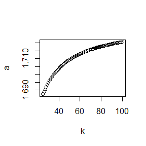

```r
k <- c(25:100)
a <- c()
for(i in k){
  a <- c(a,avalue(i))
}
plot(k,a)
```

# 实验思路如下：

### EM算法的理论步骤是根据以下关系：

$$T=(T_1,T_2,...,T_n)表示不可观测的原量，满足T \sim
EXP(\frac{1}{\lambda})$$
$$Y=(Y_1,Y_2,...,Y_n)为观测到的变量，他们满足Y_i=T_i
I(T_i \leq\tau)+\tau I(T_i >\tau)$$
$$所以第i步得到的估计量为\hat{\lambda}^{i+1} =
arg\max_{\lambda}E_{T|Y,\hat{\lambda}^i}[\log
P(Y,T|\lambda)]$$

### 下面给出上述步骤中需要用到的量的关于样本的显示表达式

$$\log P(Y,T|\lambda) = \log
P(Y_1,...Y_n,T_1,...,T_n|\lambda)$$

### 由于每个$T_i$确定后$Y_i$唯一确定，上式转化为

$$\log P(Y,T|\lambda) = \log
P(T_1,...,T_n|\lambda)=\sum_{i=1}^{n}\log P(T_i|\lambda)=\sum_{i=1}^{n}(
-\log(\lambda) - \frac{T_i}{\lambda})$$

### 于是，最开始的迭代公式转化为

$$E_{T|Y,\hat{\lambda}^i}[\log
P(Y,T|\lambda)]=E_{T|Y,\hat{\lambda}^i}[\sum_{i=1}^{n}( -\log(\lambda) -
\frac{T_i}{\lambda})]=-n\log(\lambda)-\frac{1}{\lambda}\sum_{i=1}^{n}E_{T|Y,\hat{\lambda}^i}(T_i)$$

### 下面研究式中期望的函数形式。由于诸样本独立，所以$T_i$只与$Y_i$有关，$T_i$关于$T|Y,\lambda$的条件期望可写成如下形式

$$E_{T|Y,\hat{\lambda}^i}(T_i)=E(T_i|Y,\hat{\lambda}^i)=E(T_i|Y_i,\hat{\lambda}^i)$$
### 由于$Y_i$的取值有如下形式

$$Y_i = \begin{cases} y_i & \text{if }
T_i=y_i < \tau \\ \tau & \text{if } T_i=y_i \geq \tau
\end{cases}$$

### 因此由样本决定的$E(T_i|Y_i,\lambda)$也可以分为两种情况讨论,当$y_i=\tau$时

$$E(T_i|Y_i=\tau,\hat{\lambda}^i)=E(T_i|T_i \geq
\tau,\hat{\lambda}^i)=\frac{E(T_i*I(T_i\geq\tau)|\hat{\lambda}^i)}{P(T_i\geq\tau|\hat{\lambda}^i)}=\tau+\hat{\lambda}^i$$
### 而对于$y_i < \tau$时，有如下

$$E(T_i|Y_i=y_i <
\tau,\hat{\lambda}^i)=\sum_{t\in
R}tP(T_i=t|Y_i=y_i<\tau,\hat{\lambda}^i)=y_iP(T_i=y_i|Y_i=y_i<\tau,\hat{\lambda}^i)=y_i$$
### 综上所述所求期望估计量可表示为

$$E_{T|Y,\hat{\lambda}^i}[\log
P(Y,T|\lambda)] = \begin{cases} -n\log (\lambda)-\frac{1}{\lambda}
\sum_{i=1}^{n} y_i & \text{if } Y_i=y_i < \tau \\ -n\log
(\lambda)-\frac{1}{\lambda} \sum_{i=1}^{n}(\tau+\hat{\lambda}^i) &
\text{if } Y_i=y_i = \tau \end{cases}$$
## 接下来分析EM算法的具体步骤：

### 1.E步：赋予$\hat{\lambda}^0$一个合理的初始值，比如$Y_i$的样本平均数，再以样本最大值作为$\tau$的估计（这是几乎必然的），再根据公式

$$E_{T|Y,\hat{\lambda}^i}[\log
P(Y,T|\lambda)] = \begin{cases} -n\log (\lambda)-\frac{1}{\lambda}
\sum_{i=1}^{n} y_i & \text{if } Y_i=y_i < \tau \\ -n\log
(\lambda)-\frac{1}{\lambda} \sum_{i=1}^{n}(\tau+\hat{\lambda}^i) &
\text{if } Y_i=y_i = \tau \end{cases}$$
计算隐变量对观测变量的条件期望。

### 2.M步：

$$\hat{\lambda}^{i+1} =
arg\max_{\lambda}E_{T|Y,\hat{\lambda}^i}[\log P(Y,T|\lambda)]$$
### 根据上式公式对$\hat{\lambda}^{i}$进行迭代至其收敛。具体编程实现见下方。

```r
EM_lambda <- function(y,tol = 1e-5, max_iter = 100){
  n <- length(y); lambda0 <- mean(y); tau <- max(y); k <- 0
  while (1) {
    ety <- numeric(n)
    for (i in 1:n) {
      if (y[i]<tau) {
        ety[i] <- y[i]
      }else{
        ety[i] <- tau+lambda0
      }
    }
    Et_y <- function(lambda){
      return((-1)*n*log(lambda)-(1/lambda)*sum(ety))
    }
    lambda1 <- optimize(Et_y,lower = 0,upper = 10,maximum = T)$maximum
    k <- k+1
    if (abs(lambda0-lambda1)<=tol | k == 100) {
      return(lambda1)
    }else{
      lambda0 <- lambda1
    }
  }
}
```

另一方面，由$Y_i$的形式，可写出如下的MLE算法。

```r
MLE_lambda <- function(y){
  n <- length(y); tau <- max(y)
  loglike <- function(lambda){
    lly <- numeric(n)
    for (i in 1:n) {
      if (y[i]<tau) {
        lly[i] <- -log(lambda)-y[i]/lambda
      }else{
        lly[i] <- -tau/lambda
      }
    }
    return(sum(lly))
  }
  lambdahat <- optimize(loglike,lower = 0,upper = 10,maximum = TRUE)$maximum
  return(lambdahat)
}
```

对y向量使用EM算法和MLE法得出的估计值在0.964附近，且差值极小。而y的均值为0.675，这一事实符合直觉，因为对于较大的$T_i$值实际只能观测到$\tau$，因此直接使用y的均值会低估真实的期望值$\lambda$。

```r
y <- c(0.54,0.48,0.33,0.43,1.00,1.00,0.91,1.00,0.21,0.85)
round(c(EM_lambda=EM_lambda(y),MLE_lambda=MLE_lambda(y),mean_lambda=mean(y)),6)
```

```
##   EM_lambda  MLE_lambda mean_lambda
##    0.964287    0.964288    0.675000
```

## HW8

### 11.7

求解优化问题。

```r
library(boot)
A1 <- rbind(c(2,1,1),c(1,-1,3))
a <- c(4,2,9)
b1 <- c(2,3)
simplex(a=a,A1=A1,b1=b1,maxi = T)
```

```
##
## Linear Programming Results
##
## Call : simplex(a = a, A1 = A1, b1 = b1, maxi = T)
##
## Maximization Problem with Objective Function Coefficients
## x1 x2 x3
##  4  2  9
##
##
## Optimal solution has the following values
##   x1   x2   x3
## 0.00 0.75 1.25
## The optimal value of the objective  function is 12.75.
```

```r
detach("package:boot",unload = T)
```

### Advanced R p204 3

用lapply函数写一个回归。

```r
formulas <- list(
mpg ~ disp,
mpg ~ I(1 / disp),
mpg ~ disp + wt,
mpg ~ I(1 / disp) + wt
)

out1_lapply <- lapply(formulas, function(formulas) lm(formula = formulas, data = mtcars))
```

```r
n <- length(formulas)
out1_forloop <- vector("list",length = n)
for (i in 1:n) {
  out1_forloop[[i]] <- lm(formula = formulas[[i]],data = mtcars)
}
```

### Advanced R p204 4

不用匿名函数用lapply写出一个bootstrap。

```r
bootstraps <- lapply(1:10, function(i) {
rows <- sample(1:nrow(mtcars), rep = TRUE)
mtcars[rows, ]
})

out2_lapply <- lapply(bootstraps, lm, formula = mpg ~ disp)
```

```r
n <- 10
out2_forloop <- vector("list",length = n)
for (i in 1:n) {
  bootstraps <- mtcars[sample(1:nrow(mtcars),rep = T),]
  out2_forloop [[i]] <- lm(formula = mpg ~ disp,data = bootstraps)
}
```

### Advanced R p204 5

从上述方程中提取R方。

```r
rsq <- function(mod) summary(mod)$r.squared
R2_1 <- rbind(unlist(lapply(out1_lapply, rsq)))
R2_2 <- rbind(unlist(lapply(out2_lapply, rsq)))
names1 <- c('mpg ~ disp','mpg ~ I(1 / disp)','mpg ~ disp + wt','mpg ~ I(1 / disp) + wt')
names2 <- 1:10
colnames(R2_1) <- names1
colnames(R2_2) <- names2
R2_1
```

```
##      mpg ~ disp mpg ~ I(1 / disp) mpg ~ disp + wt mpg ~ I(1 / disp) + wt
## [1,]  0.7183433         0.8596865       0.7809306              0.8838038
```

```r
R2_2
```

```
##              1         2         3        4         5         6         7
## [1,] 0.7358689 0.7553011 0.7443189 0.686968 0.7766706 0.7484335 0.7140811
##              8         9        10
## [1,] 0.7522892 0.8628006 0.7288032
```

### Advanced R p213 3

用sapply和匿名函数提取p值。

```r
trials <- replicate(
100,
t.test(rpois(10, 10), rpois(7, 10)),
simplify = FALSE
)

sapply(trials, function(result) result$p.value)
```

```
##   [1] 0.721331355 0.178518947 0.579942273 0.618444620 0.041672037 0.010478899
##   [7] 0.170511327 0.253597655 0.950611223 0.326435074 0.638860965 0.050144293
##  [13] 0.331462565 0.434463799 0.812964515 0.745296502 0.522893478 0.121617354
##  [19] 0.877200151 0.878588179 0.593288811 0.784254909 0.922489203 0.838686162
##  [25] 0.523979293 0.021278834 0.791658905 0.646727956 0.244289873 0.088616511
##  [31] 0.158602227 0.525648627 0.302728069 0.577065045 0.910025172 0.501105739
##  [37] 0.568382422 0.557204736 0.673792814 0.793378736 0.758496148 0.477749102
##  [43] 1.000000000 0.089631593 0.656828472 0.165433746 0.736786784 0.928739322
##  [49] 0.481596820 0.117354505 0.160836439 0.005246882 0.051013161 0.496080813
##  [55] 0.032518500 0.194966364 0.167377886 0.424997196 0.003880391 0.032123322
##  [61] 0.106543678 0.843665143 0.808195964 0.151096564 0.761998229 0.930434936
##  [67] 0.980083394 0.227487725 0.870693906 0.364636894 0.369172831 0.172721149
##  [73] 0.916374603 0.421674924 0.210581132 0.856317611 0.879989237 0.435476602
##  [79] 0.936187030 0.135056014 0.841295202 0.867709084 0.362238502 0.227589932
##  [85] 0.964399557 0.503331594 0.682994585 0.247891909 0.084492635 0.936773829
##  [91] 0.982167151 0.861409646 0.280824240 0.373262290 0.949555337 0.425887499
##  [97] 0.316908990 0.070625351 0.658785257 0.473241540
```

### Advanced R p214 6

用Map()和vapply()来模仿lapply的功能。

```r
mv_lapply <- function(X, f, simplify = F){
  #识别f(x)的数据类型，记录为fv
  fv <- typeof(f(x[i]))

  #生成一个长度为1，数据类型为fv的向量作为vapply的参数
  f.value <- vector(mode = fv, length = 1)

  #对x每个元使用vapply
  out <- Map(function(x) vapply(x, f, f.value), X)

  #对是否输出向量类型进行判断
  if(simplify == T){return(simplify2array(out))}
  return(out)
}

x <- c(0,1,2,3,4,5,6)
f <- function(x) x>2
unlist(lapply(x, f)) == unlist(mv_lapply(x,f))
```

```
## [1] TRUE TRUE TRUE TRUE TRUE TRUE TRUE
```

### Advanced R p365 4

写一个比chiq.test()函数更快的进行卡方检验的函数。

$$\chi^2=n(\sum_{i=1}^{r}\sum_{j=1}^{c}\frac{n_{ij}^2}{n_{i.}n_{.j}}-1)$$

```r
#两样本卡方独立性检验
fastchisqtest <- function(x,y){
  if (length(x)!=length(y)) {stop("x与y长度不一致，请检查后输入。")}
  tab <- rbind(x, y)
  n <- sum(tab)
  ni_ <- rowSums(tab)
  n_j <- colSums(tab)
  div <- tcrossprod(ni_,n_j)
  chisqe <- n*(sum(tab^2/div)-1)
  d <- length(n_j)-1
  pvalue <- pchisq(chisqe, df = d, lower.tail = F)
  return(list(chi_stat = chisqe, df = d, `p-value` = pvalue))
}
```

接下来检验该方法是否与`chisq.test`一致，结果可以看出每个值都一样。

```r
options(warn = -1)
x <- sample(1:10,replace = T); y <- sample(1:10,replace = T)
fastchisqtest(x,y)
```

```
## $chi_stat
## [1] 11.04409
##
## $df
## [1] 9
##
## $`p-value`
## [1] 0.2726992
```

```r
chisq.test(cbind(x,y))
```

```
##
##  Pearson's Chi-squared test
##
## data:  cbind(x, y)
## X-squared = 11.044, df = 9, p-value = 0.2727
```

接下里用两种方法检验该函数和`chisq.test`的差距，第一种是使用直接计算时间差，该方法有一定随机性，两种方法的用时可能会交替更短。

```r
time_fast_0 <- Sys.time()
invisible(fastchisqtest(x,y))
time_fast_1 <- Sys.time()
time_fast <- time_fast_1-time_fast_0
time_chi_0 <- Sys.time()
invisible(chisq.test(cbind(x,y)))
time_chi_1 <- Sys.time()
time_chi <- time_chi_1-time_chi_0
round(c('time of fast' = time_fast, 'time of chisq.test' = time_chi),8)
```

```
## Time differences in secs
##       time of fast time of chisq.test
##         0.00104213         0.00101304
```

另一种方法是使用microbenchmark包中的`microbenchmark`函数，计算两种方法的平均耗时，此方法下，`fastchisqtest()`表现更好。

```r
options(warn = -1)
microbenchmark::microbenchmark(
  fastchisqtest(x,y),
  chisq.test(cbind(x,y))
)
```

```
## Unit: microseconds
##                     expr  min   lq    mean median     uq   max neval
##      fastchisqtest(x, y)  7.5  8.3  11.335   9.10  10.75  53.5   100
##  chisq.test(cbind(x, y)) 73.4 80.8 108.680  87.95 115.50 311.5   100
```

### Advanced R p365 5

写一个更快版本的table。

```r
fasttable <- function(x, y){
  xtitle <- sort(unique(x))
  ytitle <- sort(unique(y))
  lx <- length(xtitle)
  ly <- length(ytitle)
  dim <- c(lx, ly)
  pr <- lx * ly
  dimnames <- list(x = xtitle, y = ytitle)
  bin <- fastmatch::fmatch(x, xtitle) +lx * fastmatch::fmatch(y, ytitle) - lx
  tab <- tabulate(bin, pr)
   tab<- array(tab, dim = dim, dimnames = dimnames)
  class(tab) <- "table"
  tab
}
```

```r
x <- sample(1:10,replace = T); y <- sample(1:10,replace = T)
table(x,y)
```

```
##     y
## x    1 2 5 8 10
##   1  0 0 0 0  1
##   2  0 1 0 0  0
##   3  0 0 0 1  0
##   5  0 1 0 0  0
##   6  1 0 0 0  0
##   9  0 0 0 3  0
##   10 0 1 1 0  0
```

```r
fasttable(x,y)
```

```
##     y
## x    1 2 5 8 10
##   1  0 0 0 0  1
##   2  0 1 0 0  0
##   3  0 0 0 1  0
##   5  0 1 0 0  0
##   6  1 0 0 0  0
##   9  0 0 0 3  0
##   10 0 1 1 0  0
```

```r
microbenchmark::microbenchmark(
  table(x, y),
  fasttable(x, y)
)
```

```
## Unit: microseconds
##             expr  min    lq   mean median    uq   max neval
##      table(x, y) 62.8 66.95 70.850   69.1 70.75 203.6   100
##  fasttable(x, y) 43.0 46.30 48.778   48.2 50.00  93.9   100
```

## HW9

### exercise

用Rcpp写一个9.8题中Gibbs样本生成器的更快的版本。

```r
library(Rcpp)
cppFunction('NumericMatrix gibbsC(int k, int thin, double a, double b, int n) {
    NumericMatrix mat(k, 2);
    int x = 0;
    double y = 0.5;
    for (int i = 0; i < k; i++) {
        for (int j = 0; j < thin; j++) {
            x = rbinom(1, n, y)[0];
            y = rbeta(1, (x + a), (n - x + b))[0];
        }
        mat(i, 0) = x;
        mat(i, 1) = y;
    }
    return(mat);
}')
```

```r
gibbsR <- function(k,thin, a, b, n) {
  mat <- matrix(0,ncol=2,nrow=k)
  x <- 0
  y <- 0.5
  for (i in 1:k) {
    for (j in 1:thin) {
      x <- rbinom(1, n, y)
      y <- rbeta(1, (x + a), (n - x + b))
    }
    mat[i,] <- c(x,y)
  }
  mat
}
```

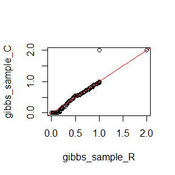

```r
k <- 100; thin <- 10; a <- 1; b <- 1; n <- 2
gibbs_sample_R <- gibbsR(k,thin, a, b, n)
gibbs_sample_C <- gibbsC(k, thin, a, b, n)
qqplot(gibbs_sample_R, gibbs_sample_C)
abline(0, 1, col = "red")
```

用`microbenchmark`比较两个函数的速度。

```r
microbenchmark::microbenchmark(gibbs_sample_R <- gibbsR(k,thin, a, b, n),
               gibbs_sample_C <- gibbsC(k, thin, a, b, n))
```

```
## Unit: microseconds
##                                        expr      min       lq      mean
##  gibbs_sample_R <- gibbsR(k, thin, a, b, n) 1213.501 1317.200 1449.7200
##  gibbs_sample_C <- gibbsC(k, thin, a, b, n)  239.901  262.401  285.1821
##    median       uq      max neval
##  1363.052 1427.451 3067.001   100
##   271.551  284.051 1110.501   100
```

从QQ图中可以看出，用R和Rcpp分别使用Gibbs样本生成器生成9.8题中的两样本随机变量x,y的各分位数近似位于y=x直线上，说明这两个生成器具有同样的效果，但使用microbenchmark测试后发现，Rcpp的计算效率比R要高许多，前者所花时间仅仅是后者的1/5不到。